# Removing outliers from D50 time series

Mike O’Brien

Dec 11, 2018

```r
data <- readRDS('data and imports/rangetest_logit_data.rds')
names(data) <- tolower(gsub(' ', '_', names(data)))
```

## The need to remove outliers

The WEA array is much more noisy than the Inner array, and there seem to be two really big outliers where the D50 model seems to have broken. Before I move into predictive modeling of D50, these outliers need to be removed.

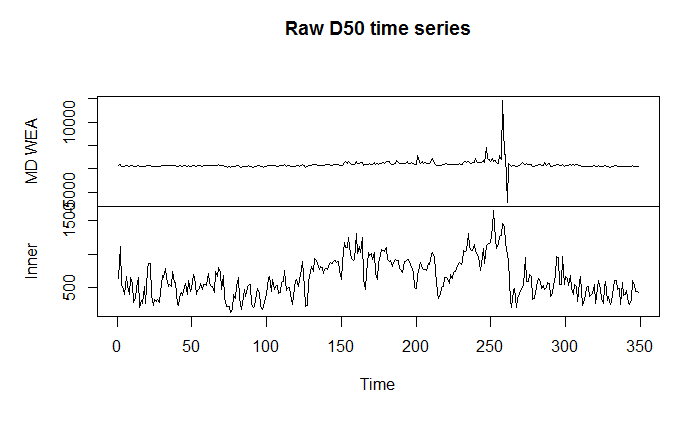

```r
plot.ts(cbind('MD WEA' = data[data$array == 'MD WEA', 'd50'],
              'Inner' = data[data$array == 'Inner', 'd50']),
        main = 'Raw D50 time series')
```

There are two methods for finding and replacing time series outliers: `tsoutliers::tso` (‘intervention analysis’) and `forecast::tsclean` (Friedman’s “super smoother”). Run the intervention analysis first.

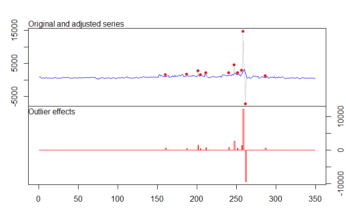

```r
d50_wea <- ts(data[data$array == 'MD WEA', 'd50'])

interv_wea <- tsoutliers::tso(d50_wea, types = 'AO',
               tsmethod = 'auto.arima',
               maxit.iloop = 10, maxit.oloop = 10)

plot(interv_wea)
```

This removes the two big outliers, but seems to replace the large positive outlier with another outlier.

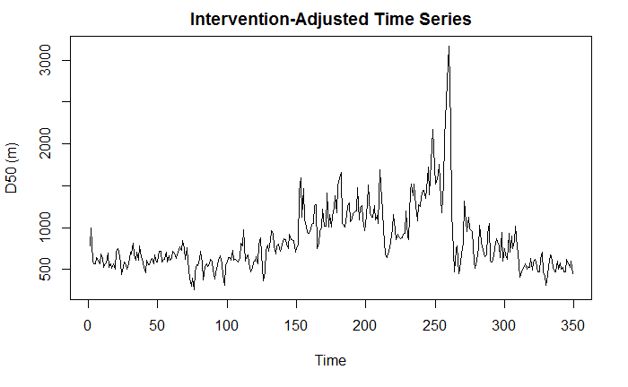

```r
plot(interv_wea$yadj,
     main = 'Intervention-Adjusted Time Series',
     ylab = 'D50 (m)')
```

Using the super smoother also results in weird behavior, just inserting a flat line through that section of the time series.

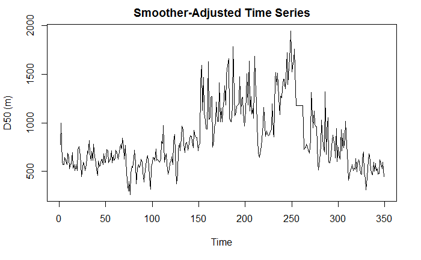

```r
smu_wea <- forecast::tsclean(d50_wea)
plot(smu_wea,
     main = 'Smoother-Adjusted Time Series',
     ylab = 'D50 (m)')
```

Here’s what they look like put together.

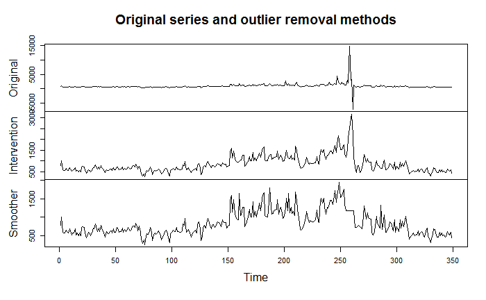

```r
plot.ts(cbind('Original' = d50_wea,
              'Intervention' = interv_wea$yadj,
              'Smoother' = smu_wea),
        main = 'Original series and outlier removal methods')
```

## The need to preprocess the data

It seems that the excessively large/negative outliers (one is 14km, the other -7km) are messing with the performance of the outlier detection algorithms. I am struggling with how to deal with this, but I’ve decided to preprocess the data before running the unsupervised outlier detection.

- If a D50 value is greater than 4xs the values before *and* after it,
- Or, if a D50 value is negative,
- Replace with the mean of the values before and after it.

This doesn’t seem to change the performance of the intervention algorithm all that much, but the performance of the smoother is much more promising, with the largest values still less than 2km.

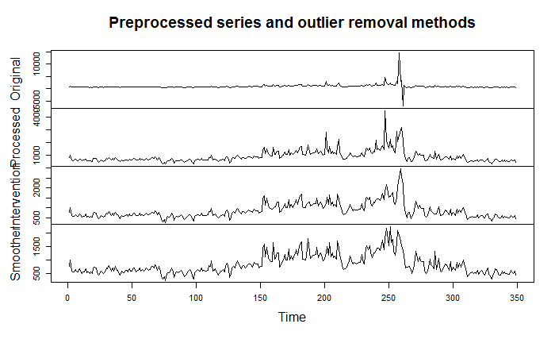

```r
plot.ts(cbind('Original' = d50_wea,
              'Processed' = d50_wea_adj,
              'Intervention' = interv_wea_adj$yadj,
              'Smoother' = smu_wea_adj),
        main = 'Preprocessed series and outlier removal methods')
```

## Remove outliers

Lumping everything together:

```r
data_adj <- data %>%
  group_by(array) %>%
  mutate_at(vars(grep('d\\d\\d', names(.))),
            funs(adj = ifelse((. > (4 * lead(.)) & . > (4 * lag(.))) |
                                   . <= 0,
                                 ((lag(.) + lead(.)) / 2), .))) %>%
  mutate_at(vars(grep('_adj', names(.))),
            funs(forecast::tsclean(.)))
```

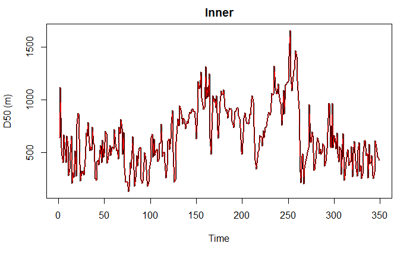